# Electric Vehicles and Income Patterns in Washington State

## Analysis of Median Household Income

### Questions

- How does median income differ across counties?
- Do higher income counties display a stronger adoption of EV vehicles?
- Do lower income counties display a weaker adoption of EV vehicles?

### Median Household Income Data

Through the HDPulse Data program, Median Household income Data is shared by the National Institute on Minority Health and Health Disparities. It represents survey respondents from the American Community Survey (ACS) who are analyzed within each geographic region. This data includes features such as the **statistical population**, such as all of the households in counties throughout Washington State. The data includes a **sample**, which includes the individual households that were surveyed by the American Community Survey (ACS). The survey respondents are analyzed within each geographic region. For the **time & place**, the time period between 2019-2023 included locations throughout Washington State. The data’s **features** included Median household income, county FIPS codes, and the US ranking as well.

### Data Preparation Steps

To further understand how income varies across Washington’s counties, I had to **load data** by reading the HDPulse CSV file, and skip the first four header rows to reach actual data. Then I **selected specific rows** using slice(3:41) to remove summary rows for the ‘United States’ and ‘Washington State’, which allowed us to keep only county data. I **renamed the columns** to change columns that were unclear to more readable names.

Lastly, I **converted data types** using parse_number() to remove commas and trailing spaces. In the raw dataset, the numeric cells contained spaces and commas, so R read them as text. Because of that, it wasn’t possible to create visualizations or calculations until I converted these text values into numeric format for the Rank and Income columns.

```r
MEDIAN_INCOME <- read.csv("HDPulse_data_export_2.csv", skip = 4) |>
    slice(3:41) |>
    rename(Income = Value..Dollars.,
          Rank_within_US = Rank.within.US..of.3141.counties.,
          ID = FIPS) |>
    mutate(Rank_within_US = parse_number(Rank_within_US),
          Income = parse_number(Income))
```

### Results

I created a bar graph of the median household income to understand how income varies across counties. The geom_col method places bars onto the plot. To make the bars stand out more clearly against the minimal theme background, I used the color red. I used the reorder(County, Income) function to sort counties from lowest to highest income, which allowed us to see the levels of household income amongst Washington’s counties more clearly. To add labels and formatting, I used labs() to add a title, subtitle, axis, labels, and caption of the data source. I used horizontal bars to visualize the data more easily, so I placed County on the y axis and Income on the x axis.

[figure not shown]

```r
MEDIAN_INCOME|>
    ggplot(aes(y = reorder(County, Income), x = Income)) +
    geom_col(fill = "red") +
    labs(x = "County",
         y = "Median Household Income",
         title = "King County and Snohomish County are most affluent in Washington State",
         subtitle = "Median Household Income throughout Washington Counties, 2023-2025",
         caption = "Data Available at: https://hdpulse.nimhd.nih.gov") +
    theme_minimal()
```

### Median Household Income Results

I am checking the variance of income across counties within Washington because I want to identify general levels of income and the level of inequality between counties. I chose the median as a central value because it exemplifies a great middle-point between the varying socioeconomic status’s within Washington’s counties. Because King County’s income as $122,000+ is greatly higher than other Washington counties, the median value can give us a middle-ground that does not skew too heavily above or below the average income. This is specially meaningful because it is helpful towards identifying certain counties that may need more assistance from the state.

## Analysis of Income and EVs Correlation

### Questions

As the final step, you want to see the correlation between electric vehicles and median income in Washington state counties. I am using the same data sets wrangled and used in the previous steps to conduct the analysis.

Specifically, I want to see if the counties with higher income more likely to have more EVs? What patterns or trends appear when plotting EV count vs median income?

### Data Preparation

I are using the same “Electric Vehicles” and “Median Income” data sets I highlighted above to do the joint analysis. No new data sets are introduced here.

To conduct the correlation analysis, I first needed to join the data frames by county to be able to compare both numeric values of income and number of vehicles. However, I discovered the county names didn’t match: in the EV dataset, counties appear as just the name (e.g., “King”), while in the Income data frame, they appear as “King County.” To fix this, I removed the word “County” from Income data frame entries using str_replace(). The function takes the pattern I want to remove, in this case ” County,” and replaces it with an empty string. After that, I used mutate() to write the cleaned names back into the County column in the MEDIAN_INCOME data frame.

I learned the str_replace() function from examples on [Posit Cloud learning platform](https://posit.cloud/learn/recipes/strings/StringsD)

```r
MEDIAN_INCOME <- MEDIAN_INCOME |>
  mutate(County = str_replace(County, pattern = " County", replacement = ""))

combined_income_ev <- MEDIAN_INCOME |>
   left_join(electric_vh_by_counties, by = join_by("County"))

combined_income_ev |> glimpse()
```

```
Rows: 39
Columns: 5
$ County             <chr> "Whitman", "Ferry", "Wahkiakum", "Okanogan", "Pacif…
$ ID                 <int> 53075, 53019, 53069, 53047, 53049, 53023, 53027, 53…
$ Income             <dbl> 52893, 54650, 57091, 60293, 62350, 62411, 63539, 63…
$ Rank_within_US     <dbl> 2496, 2373, 2178, 1884, 1692, 1688, 1580, 1561, 142…
$ Number_of_vehicles <int> 136, 12, 29, 94, 89, NA, 257, 24, 30, 87, 455, 437,…
```

### Results

The best way to show the correlation is the scatter plot visualization. I use color to show each county’s rank in the United States. Counties with higher ranks have darker colors, and counties with lower ranks have lighter colors, that is why I can easily see which counties are doing better or worse.

I also use scale_y_log10() for the vertical axis. King County and Snohomish County have way more EVs than the other counties, so they are outliers. If I used a normal y-axis, the smaller counties would look almost flat and close to 0. Scale_y_log10() “shrinks” the big numbers so I can see all counties more clearly and it does not change the actual data values or the rank. It only changes how the chart is displayed to make the differences more readable, even though some have much higher EV counts.

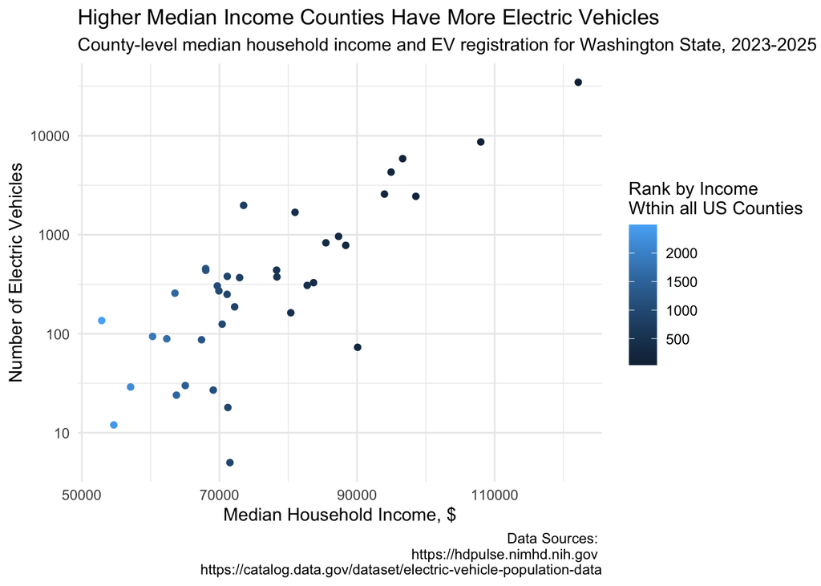

```r
combined_income_ev |>
  ggplot(aes(x = Income, y = Number_of_vehicles, color = Rank_within_US)) +
  geom_point() +
  scale_y_log10() +
  labs(x = "Median Household Income, $",
       y = "Number of Electric Vehicles",
      color = "Rank by Income\nWthin all US Counties",
      title = "Higher Median Income Counties Have More Electric Vehicles",
      subtitle = "County-level median household income and EV registration for Washington State, 2023-2025",
      caption = "Data Sources: \nhttps://hdpulse.nimhd.nih.gov \n https://catalog.data.gov/dataset/electric-vehicle-population-data") +
  theme_minimal()
```

### Correlation Results

I also see that counties with higher median incomes tend to have a higher rank within all US counties, as shown by the color gradient in the plot, which again highlights the connection between income and EV adoption.

This pattern tells us that income level may be an important factor in EV adoption. It also shows that additional policies or incentives for lower-income counties could help increase electric vehicle usage across the state, especially since choosing electric vehicles can support environmental and ecology goals and help reduce the impacts of global warming.

## General Conclusions

The analysis displays a strong correlation between county income levels and the adoption of electric vehicles throughout Washington State. King County (122,00+) and Snohomish County (100,000+) are leaders in the registrations of electrical vehicles, tied with a higher median income. On the other hand, lower income counties, such as Whitman (52,000) have many less electric vehicles. This pattern exemplifies that Washington’s high rate of adopting electric vehicles may be driven by few wealthier urban counties, instead of being distributed evenly across the state.

As for the limitations, I likely overestimated the direct role of income. There are many other factors that could interfere with the correlation between EVs and higher median income, such as type of housing and the density of population. Since King and Snohomish counties are outliers, these counties could potentially skew results. I may have underestimated by simply using medians on the county-level, which could limit the variation within a county.

In terms of future directions, this could incorporate action on behalf of the state to invest in certain lower-income communities, grasping urban versus rural patterns within Washington counties, or surveying residents about barriers to adopting Electric Vehicles.

## Project Summary

**Author:** Liza Snizhko

**Data Sets:**

- [Electric Vehicle Population Data](https://catalog.data.gov/dataset/electric-vehicle-population-data)
- Income (Median household income) for Washington by County

**Basic Tools Used:**

- group_by(), summarize(), slice_sample(), slice(), mutate(), parse_number(), str_replace(), reorder(), str_glue()
  - str_replace() - [Posit Cloud learning platform](https://posit.cloud/learn/recipes/strings/StringsD)
  - str_glue() - [R for Data Science (Chapter 14)](https://r4ds.hadley.nz/strings.html#sec-glue)

**Intermediate/Novel Tool Used:**

- Choropleth Maps, with reference materials including:
  - [Rdocumentation.org with the tigris documentation](https://rdocumentation.org/packages/tigris/versions/2.2.1/topics/counties)
  - [R Charts “Join map and data” section](https://r-charts.com/spatial/choropleth-map-ggplot2/#join)
  - [R Charts tutorial for creating the simple maps with sf package](https://r-charts.com/spatial/maps-ggplot2)
- Join (left_join()):
  - [R for Data Science (chapter 19)](https://r4ds.hadley.nz/joins.html#sec-mutating-joins)